# Data 606 Chapter 3 Homework

Yohannes Deboch

February 24, 2019

```r
library(ggplot2)
library(dplyr)
```

Graded: 3.2 (see normalPlot), 3.4, 3.18 (use qqnormsim from lab 3), 3.22, 3.38, 3.42

3.2 Area under the curve, Part II. What percent of a standard normal distribution N(µ = 0,σ = 1) is found in each region? Be sure to draw a graph. (a) Z > −1.13 Answer:

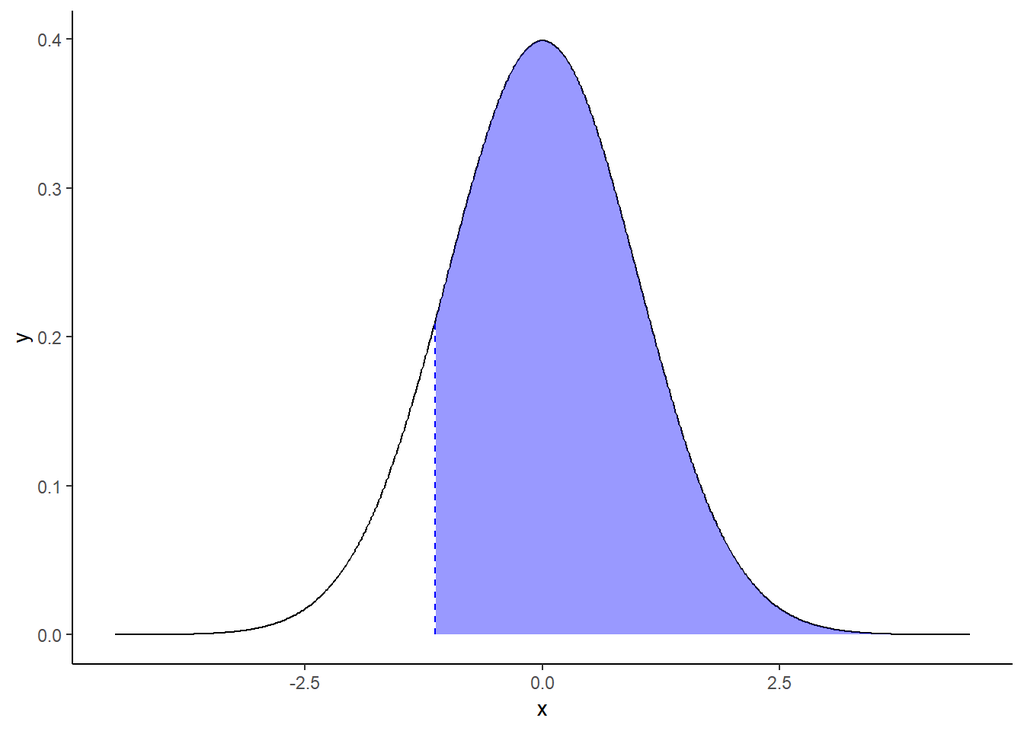

```r
x <- seq(-4.5,4.5,0.01)
y <- dnorm(x, 0, 1)
df <- data.frame(x,y)
# Plot
df %>%
    ggplot(aes(x,y))+geom_line()+
    geom_segment(aes(-1.13,0,xend = -1.13, yend = dnorm(-1.13,0,1)), linetype=2, col="blue")+
    geom_ribbon(data = subset(df,x>-1.13), aes(x = x , ymax = y), ymin = 0, fill="blue",alpha=0.4)+theme_classic()
```

```r
round(100*pnorm(-1.13, 0, 1, lower.tail = FALSE), 2)
```

```
## [1] 87.08
```

Answer:

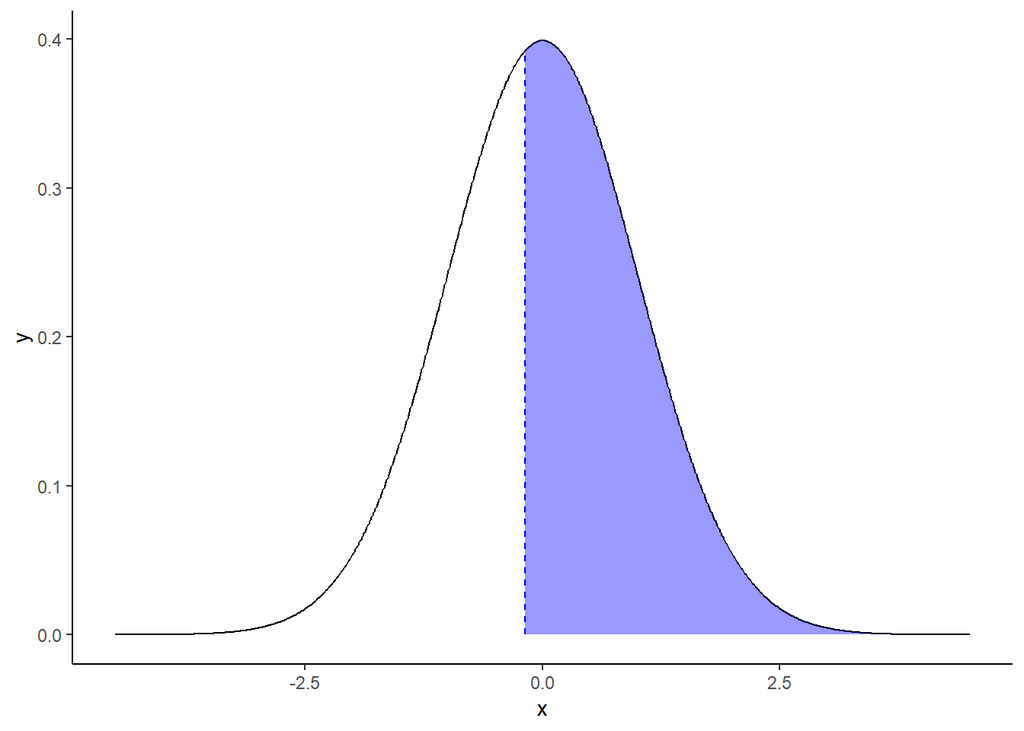

```r
cut_point <- -0.18
x <- seq(-4.5,4.5,0.01)
y <- dnorm(x, 0, 1)
df <- data.frame(x,y)
# Plot
df %>%
    ggplot(aes(x,y))+geom_line()+
    geom_segment(aes(cut_point,0,xend = cut_point, yend = dnorm(cut_point,0,1)), linetype=2, col="blue")+
    geom_ribbon(data = subset(df,x>cut_point), aes(x = x , ymax = y), ymin = 0, fill="blue",alpha=0.4)+theme_classic()
```

```r
round(100*pnorm(cut_point, 0, 1, lower.tail = TRUE), 2)
```

```
## [1] 42.86
```

42.86% of the standard normal distribution lies < -0.18 (c) Z > 8

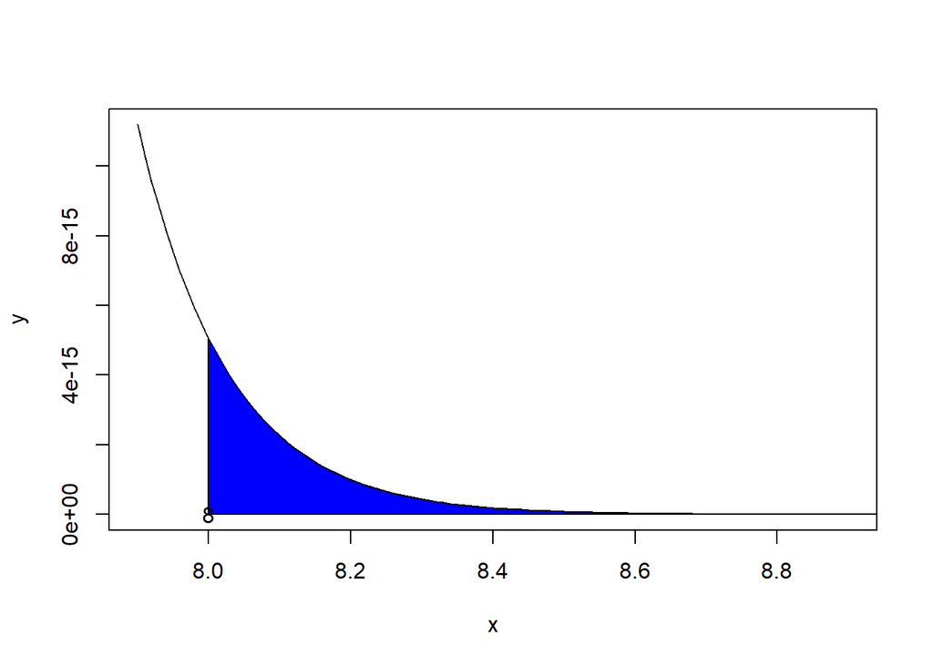

```r
x <- seq(7.9, 8.9, by = 0.01)
y <- dnorm(x,0,1)
v<-seq(8,9,0.01)
w<-dnorm(v,0,1)
plot(x,y,type = 'l')
polygon(c(8,v,9),c(0,w,0),col='blue')
text(x=8,y=0,"8")
```

```r
options(scipen=16)
100*pnorm(cut_point, 0, 1, lower.tail = FALSE)
```

```
## [1] 57.14237
```

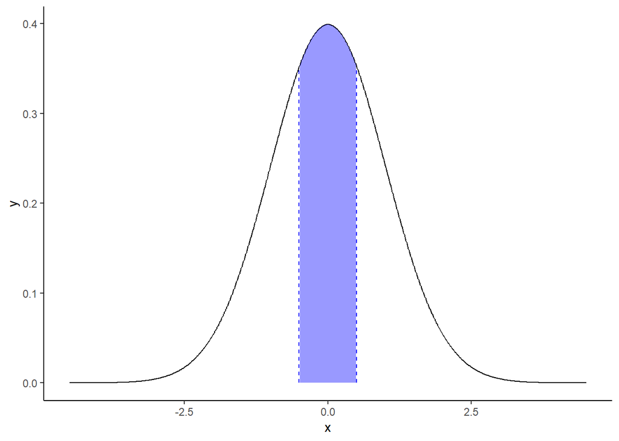

```r
cut_point <- 0.5
x <- seq(-4.5,4.5,0.01)
y <- dnorm(x, 0, 1)
df <- data.frame(x,y)
# Plot
df %>%
    ggplot(aes(x,y))+geom_line()+
    geom_segment(aes(-cut_point,0,xend = -cut_point, yend = dnorm(-cut_point,0,1)), linetype=2, col="blue")+
    geom_segment(aes(cut_point,0,xend = cut_point, yend = dnorm(cut_point,0,1)), linetype=2, col="blue")+
    geom_ribbon(data = subset(df,x>-cut_point & x < cut_point), aes(x = x , ymax = y), ymin = 0, fill="blue",alpha=0.4)+theme_classic()
```

```r
round(100*pnorm(-cut_point, 0, 1, lower.tail = TRUE)-pnorm(-cut_point, 0, 1, lower.tail = TRUE), 2)
```

```
## [1] 30.55
```

3.4 Triathlon times, Part I. In triathlons, it is common for racers to be placed into age and gender groups. Friends Leo and Mary both completed the Hermosa Beach Triathlon, where Leo competed in the Men, Ages 30 - 34 group while Mary competed in the Women, Ages 25 - 29 group. Leo completed the race in 1:22:28 (4948 seconds), while Mary completed the race in

1:31:53 (5513 seconds). Obviously Leo finished faster, but they are curious about how they did within their respective groups. Can you help them? Here is some information on the performance

of their groups:

• The finishing times of the Men, Ages 30 - 34 group has a mean of 4313 seconds with a standard deviation of 583 seconds.

• The finishing times of the Women, Ages 25 - 29 group has a mean of 5261 seconds with a standard deviation of 807 seconds.

• The distributions of finishing times for both groups are approximately Normal. Remember: a better performance corresponds to a faster finish.

1. Write down the short-hand for these two normal distributions.

Answer:The distribution of the finishing times of the Men, Ages 30 - 34 group is $N(\mu=4313,\sigma= 583).$

The distribution of the finishing times of the Women, Ages 25 - 29 group is $N(\mu=5261 , \sigma=807)$

2. What are the Z-scores for Leo’s and Mary’s finishing times? What do these Z-scores tell you? Answer:

```r
(4948 - 4313)/583
```

```
## [1] 1.089194
```

```r
(5513-5261)/807
```

```
## [1] 0.3122677
```

Leo’s Z score = 1.089194 Mary’s Z Score = 0.3122677 Leo is faster than Mary.

3. Did Leo or Mary rank better in their respective groups? Explain your reasoning.

4. What percent of the triathletes did Leo finish faster than in his group? Answer:

```r
pnorm(4948,4313,583, lower.tail = FALSE)
```

```
## [1] 0.1380342
```

```r
pnorm(5513,5261,807, lower.tail = FALSE)
```

```
## [1] 0.3774186
```

Answer: If the distributions of finishing time are not nearly normal the answer to part (b)-(e) won’t change, for large sample size in both cases the data will approximately follow normal distribtuion by central limit theorme.

3.18 Heights of female college students. Below are heights of 25 female college students.

```r
heights <- c(54, 55, 56, 56, 57, 58, 58, 59, 60, 60, 60, 61, 61, 62, 62, 63, 63, 63, 64, 65, 65, 67, 67, 69, 73)
mean_height <- 61.52
std_height <- 4.58
```

1. The mean height is 61.52 inches with a standard deviation of 4.58 inches. Use this information to determine if the heights approximately follow the 68-95-99.7% Rule.

```r
length(heights[heights >=( mean_height - std_height) & heights <=( mean_height + std_height)])/length(heights)*100
```

```
## [1] 68
```

```r
length(heights[heights >=( mean_height - 2*std_height) & heights <=( mean_height + 2*std_height)])/length(heights)*100
```

```
## [1] 96
```

```r
length(heights[heights >=( mean_height - 3*std_height) & heights <=( mean_height + 3*std_height)])/length(heights)*100
```

```
## [1] 100
```

2. Do these data appear to follow a normal distribution? Explain your reasoning using the graphs provided below.

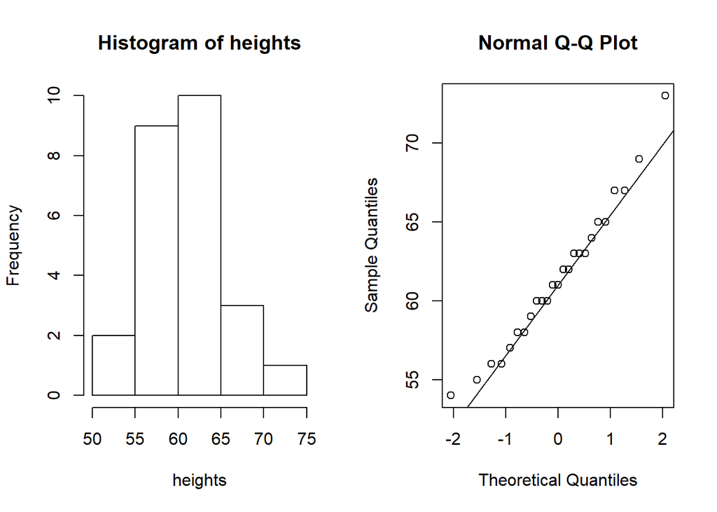

```r
par(mfrow=c(1,2))
hist(heights)
qqnorm(heights)
qqline(heights)
```

The appear to follow a normal distribution. From the histogram we can see that the histogram shows a symmetrical bell shape. From the Q-Q plot we can see that the quantiles are approximately on the 45 degree angle on the reference line which suggests normality of the data.

3.22 Defective rate. A machine that produces a special type of transistor (a component of computers) has a 2% defective rate. The production is considered a random process where each transistor is independent of the others.

1. What is the probability that the 10 th transistor produced is the first with a defect?

```r
dbinom(1,size = 10, prob = 0.02)
```

```
## [1] 0.1667496
```

```r
dbinom(0,size = 100, prob = 0.02)
```

```
## [1] 0.1326196
```

The probability that the machine produces no defective transistors in a batch of 100 is 0.1326196.

3. On average, how many transistors would you expect to be produced before the first with a defect? What is the standard deviation?

```r
1/0.02
```

```
## [1] 50
```

On average 50 transistors need to be produced before thea defect.

```r
sqrt((1-0.02)/0.02^2)
```

```
## [1] 49.49747
```

The standard deviationis 49.49747.

4. Another machine that also produces transistors has a 5% defective rate where each transistor is produced independent of the others. On average how many transistors would you expect to be produced with this machine before the first with a defect? What is the standard deviation?

```r
1/0.05
```

```
## [1] 20
```

On average 20 transistors need to be produced before thea defect.

```r
sqrt((1-0.05)/0.05^2)
```

```
## [1] 19.49359
```

The standard deviationis 19.49359.

5. Based on your answers to parts (c) and (d), how does increasing the probability of an event affect the mean and standard deviation of the wait time until success?

Answer: When probability increases mean and standard deviation decreaesses.

3.38 Male children. While it is often assumed that the probabilities of having a boy or a girl are the same, the actual probability of having a boy is slightly higher at 0.51. Suppose a couple plans to have 3 kids.

1. Use the binomial model to calculate the probability that two of them will be boys. Answer:

```r
dbinom(2,3,0.51)
```

```
## [1] 0.382347
```

Two of them will be boys probability is 0.382347.

2. Write out all possible orderings of 3 children, 2 of whom are boys. Use these scenarios to calculate the same probability from part (a) but using the addition rule for disjoint outcomes. Confirm that your answers from parts (a) and (b) match. The ordering is
1. BBG
2. BGB
3. GBB where B boys, G is Girl

```r
p <- 0.51
BBB <- p*p*(1-p)
BGB <- p*(1-p)*p
GBB <- (1-p)*p*p
total <- BBB + BGB + GBB
total
```

```
## [1] 0.382347
```

Probability using the scenario is 0.382347 which is same as part (a)

3. If we wanted to calculate the probability that a couple who plans to have 8 kids will have

3 boys, briefly describe why the approach from part (b) would be more tedious than the approach from part (a)

Answer: The method in (b) will be tedious and time consuming because we’ve to do the calculations for all 56 combinations of boys and girls.

3.42 Serving in volleyball. A not-so-skilled volleyball player has a 15% chance of making the serve, which involves hitting the ball so it passes over the net on a trajectory such that it will land in the opposing team’s court. Suppose that her serves are independent of each other.

1. What is the probability that on the 10 th try she will make her 3 rd successful serve? Answer:

```r
dbinom(2, 9, 0.15)*0.15
```

```
## [1] 0.03895012
```

The probability is 0.03895012.

2. Suppose she has made two successful serves in nine attempts. What is the probability that her 10 th serve will be successful?

Answer: The probability is 0.15 since each of the serve is independent of the other serves. (c) Even though parts (a) and (b) discuss the same scenario, the probabilities you calculated should be different. Can you explain the reason for this discrepancy?

Answer: In case of (a) we’re not taking into account previous serves Part (a) is the sum of several independent events. 3 successful serves in 10 attempts. Here the probability of total 3 successful serve.

2. is one independent event that is 10th serve will be successful.